# My Document

Deden Istiawan-Institut Teknologi Statistika dan Bisnis Muhammadiyah

2023-01-18

# Algoritma ID3

#### Pengertian

Algoritma ID3 atau Iterative Dichotomiser 3 adalah sebuah metode yang digunakan untuk membuat pohon keputusan yang telah dikembangkan oleh J. Ross Quinlan sejak tahun 1986. Algoritma ID3 melakukan pencarian secara menyeluruh pada semua kemungkinan pohon keputusan. Algoritma ID3 berusaha membangun decision tree (pohon keputusan) secara top-down (dari atas ke bawah).

#### Struktur Pohon Keputusan

Struktur pohon keputusan terdiri dari root node (node akar), internal node (node cabang), dan leaf node. Pembentukan pohon klasifikasi dengan algoritma ID3 melalui dua langkah, yaitu :

1. Menghitung nilai entropy
2. Menghitung nilai information gain dari setiap variabel

# Tahapan Algoritma ID3

Tahapan Algoritma ID3 dibagi menjadi 6 tahapan, yaitu :

#### Menyiapkan Dataset

Dataset yang digunakan yaitu dataset yang berlabel nominal. Untuk algoritma ID3 menggunakan data jenis klasifikasi.

#### Menghitung Nilai Entropy

Konsep Entropy digunakan untuk mengukur “seberapa informatifnya” sebuah node (yang biasanya disebut seberapa baiknya).

Rumus Entropy :
$$\begin{equation}
\operatorname{entropy}(s)=-p_{+} \log _2 p_{+}-p_{-} \log _2 p_{-}
\end{equation}$$
Keterangan :

S = Himpunan (dataset) Kasus

𝑝_+ = jumlah label yang bersolusi positif (mendukung) dibagi total kasus.

𝑝_− = jumlah label yang bersolusi negative (tidak mendukung) dibagi total kasus.

#### Menghitung Nilai Information Gain

Information gain adalah kriteria pemisahan yang menggunakan pengukuran entropy. Information gain digunakan untuk mengukur efektivitas suatu atribut dalam mengklasifikasikan data.

Rumus Information Gain :
$$\begin{equation}
\operatorname{Gain}(A)=\operatorname{entropy}(s)-\sum_{i=1}^k \frac{|S i|}{|S|} x \operatorname{entropy}(S i)
\end{equation}$$
Keterangan :

S = Ruang data (sampel)

A = Atribut

⎸𝑆𝑖⎹ = jumlah sampel data

⎸𝑆⎹ = jumlah seluruh sampel data

Entropy (Si) = untuk sampel-sampel yang memiliki nilai i

#### Menentukan Root Node (Node Akar)

Root node atau node akar ditentukan berdasarkan nilai information gain yang telah di cari. Atribut dengan nilai information gain tertinggi akan menjadi root node nya. Atribut yang telah di pilih tidak diikutkan lagi ke perhitungan entropy dan information gain selanjutnya.

#### Membuat Node Cabang

Node cabang di dapat dari perhitungan entropy dan information gain selanjutnya.

#### Ulangi Langkah 2-4

Mengulangi langkah 2-4 hingga membentuk pohon keputusan.

# Eksperimen Algoritma ID3

Berikut ini merupakan eksperimen menggunakan Algoritma ID3

#### Library

```r
library(dplyr)
```

#### Loading Dataset

pada eksperimen ini menggunakan data Penguin yang bersumber dari Kaggle

```r
library(readxl)
Data_penguin <- read_excel("Data penguin.xlsx")
View(Data_penguin)
```

#### Menghitung Nilai Entropy

Nilai entropy dapat dihitung dengan cara berikut

```r
IsPure <- function(data) {
  length(unique(data[,ncol(data)])) == 1
}
Entropy <- function( vls ) {
  res <- vls/sum(vls) * log2(vls/sum(vls))
  res[vls == 0] <- 0
  -sum(res)
}
```

Menghitung nilai entropy untuk kolom Culmen.Length

```r
print(Entropy(Data_penguin$Culmen.Length))
```

```
## [1] 8.406704
```

Menghitung nilai entropy untuk kolom Culmen.Depth

```r
print(Entropy(Data_penguin$Culmen.Depth))
```

```
## [1] 8.40822
```

Menghitung nilai entropy untuk kolom Flipper.Length

```r
print(Entropy(Data_penguin$Flipper.Length))
```

```
## [1] 8.414352
```

Menghitung nilai entropy untuk kolom Body.Mass

```r
print(Entropy(Data_penguin$Body.Mass))
```

```
## [1] 8.392099
```

#### Nilai Information Gain

Menghitung nilai information gain dapat dilakukan dengan cara berikut :

```r
InformationGain <- function( tble ) {
  tble <- as.data.frame.matrix(tble)
  entropyBefore <- Entropy(colSums(tble))
  s <- rowSums(tble)
  entropyAfter <- sum (s / sum(s) * apply(tble, MARGIN = 1, FUN = Entropy ))
  informationGain <- entropyBefore - entropyAfter
  return (informationGain)
}
```

Menghitung nilai informtion gain untuk kolom Culmen.Length

```r
InformationGain(table(Data_penguin[,c('Culmen.Length', 'Species')]))
```

```
## [1] 1.15916
```

Menghitung nilai informtion gain untuk kolom Culmen.Depth

```r
InformationGain(table(Data_penguin[,c('Culmen.Depth', 'Species')]))
```

```
## [1] 0.9514694
```

Menghitung nilai informtion gain untuk kolom Flipper.Length

```r
InformationGain(table(Data_penguin[,c('Flipper.Length', 'Species')]))
```

```
## [1] 0.9853352
```

Menghitung nilai informtion gain untuk kolom Body.Mass

```r
InformationGain(table(Data_penguin[,c('Body.Mass', 'Species')]))
```

```
## [1] 0.9216235
```

Menghitung nilai informtion gain untuk kolom Species

```r
InformationGain(table(Data_penguin[,c('Species', 'Species')]))
```

```
## [1] 1.514707
```

#### Membuat Pohon Keputusan

Pohon keputusan dapat dibuat dengan cara berikut

```r
library(rpart)
```

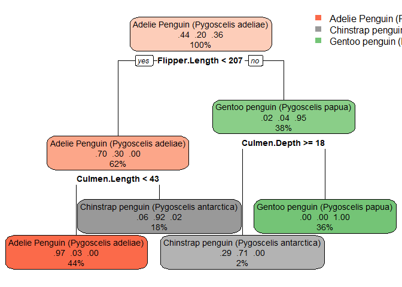

```r
library(rpart.plot)
tree<- rpart(Species~., data = Data_penguin, method = 'class')
rpart.plot(tree)
```

# Referensi

1. https://rpubs.com/gluc/ID3
2. https://rpubs.com/Eliyanto29/Entropy_and_Information_G
3. https://medium.com/analytics-vidhya/visualizing-decision-tree-with-r-774f58ac23c